# Project

Mohammad Mehdi Razavi

July, 2018

# spotify analysis

[figure not shown]

```r
library(spotifyr)
library(dplyr)
library(readr)
library(billboard)
library(purrr)
library(httr)
library(highcharter)
library(wordcloud2)
library(tidytext)
library(tm)
library(stringr)
Sys.setenv(JAVA_HOME='C:\\Program Files\\Java\\jdk1.8.0_171//')
library(rJava)
library(qdap)
library(tidyr)
library(ggplot2)
library(ggthemes)
library(ggpubr)
library(corrplot)
library(dplyr)
library(lubridate)
library(ggplot2)
library(zoo)
library(viridis)

source("data/R/func.R")
source("data/R/last-fm-api.R")
load("data/tidy_scrobbles_with_genres.RData")

#get spotify api token
Sys.setenv(SPOTIFY_CLIENT_ID = "b261826861964be98c5a1ab64add0225")
Sys.setenv(SPOTIFY_CLIENT_SECRET = "68be53fad75b45e4aac5c75b12c571b9")
main_data<-read.csv("main_data.csv")
billboard_songs_data<-read.csv("billboard_songs_data.csv")
million3 = read.csv("data2.csv")
```

You can see the top 40 songs that have most danceability.You can use these songs for your party :)

```r
main_data %>% arrange(-danceability) %>% head(40) %>% hchart(.,"column", hcaes(x=track_name, y = danceability))
```

[interactive chart not shown]

```r
billboard_songs_data %>% arrange(-danceability) %>% head(40) %>% hchart("column", hcaes(x=track_name, y = danceability))
```

[interactive chart not shown]

Here you can see the top 4000 words that used in the lyrics of songs that are in the billboard chart of America. because in knit time it doesn’t show the picture i pu the screen shot here.

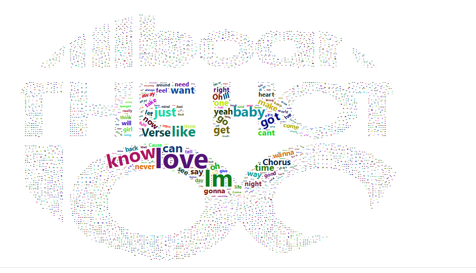

Adding the number of streams from 3million songs data to the billboard data.

```r
million3 -> million3.1
million3.1$Date = str_sub(million3.1$Date, 1,4)
million3.1 %>%
  select(Track.Name, Artist, Streams, Date) ->million3.1
million3.1$Date = as.numeric(million3.1$Date)
billboard_songs_data$Track.Name = billboard_songs_data$track_name
left_join(million3.1, billboard_songs_data, by = "Track.Name")-> tmp
tmp %>% filter(!is.na(year)) -> billboard.with.streams
```

Top 10 streamed songs on spotiy.

```r
million3 %>%
  group_by(Track.Name) %>%
    mutate(count.of.stream = max(Streams)) %>%
      select(Track.Name, count.of.stream) %>%
        unique() %>%
          arrange(-count.of.stream)-> countedsongs
hchart(countedsongs %>% head(10),"column", hcaes(x=Track.Name, y = count.of.stream)) %>% hc_add_theme(hc_theme_ffx())
```

[interactive chart not shown]

```r
temp = countedsongs %>% head(10)
hchart(temp,"column", hcaes(x=Track.Name, y = count.of.stream)) %>% hc_add_theme(hc_theme_ffx())
```

[interactive chart not shown]

Top 10 energy in the songs.

```r
billboard.with.streams %>%
  arrange(-energy) %>%
    select(Track.Name,energy) %>%
      unique() %>%
        head(10) -> temp

hchart(temp,"column" , hcaes(x=Track.Name, y = energy)) %>% hc_add_theme(hc_theme_db())
```

[interactive chart not shown]

Top 10 dancibility in the songs.

```r
billboard.with.streams %>%
  arrange(-danceability) %>%
    select(Track.Name,danceability) %>%
      unique() %>%
        head(10) -> temp

hchart(temp,"column" , hcaes(x=Track.Name, y = danceability)) %>% hc_add_theme(hc_theme_db())
```

[interactive chart not shown]

Top 10 duration in all songs.

```r
billboard.with.streams %>%
  arrange(-duration_ms) %>%
    select(Track.Name,duration_ms) %>%
      unique() %>%
        head(10) -> temp

hchart(temp,"column" , hcaes(x=Track.Name, y = duration_ms)) %>% hc_add_theme(hc_theme_db())
```

[interactive chart not shown]

Top artists in billboard(artists that have more songs in all time billboard history)

```r
billboard.with.streams %>%
  select(Track.Name, Artist) %>%
    unique() %>%
      group_by(Artist) %>%
        mutate(count = n()) %>%
          select(Artist, count) %>%
            unique() %>%
              arrange(-count) %>%
                head(10) -> temp

hchart(temp,"column" , hcaes(x=Artist, y = count)) %>% hc_add_theme(hc_theme_db())
```

[interactive chart not shown]

Is there any relation between dancability and energy of a song?

```r
cor.test(billboard.with.streams$danceability, billboard.with.streams$energy, method = "pearson")
```

```
##
##  Pearson's product-moment correlation
##
## data:  billboard.with.streams$danceability and billboard.with.streams$energy
## t = 32.952, df = 356490, p-value < 2.2e-16
## alternative hypothesis: true correlation is not equal to 0
## 95 percent confidence interval:
##  0.05183206 0.05837740
## sample estimates:
##        cor
## 0.05510532
```

as you can see the correlation is 0.05. so there is not a linear relation between these two.

Is there an relation between tempo and energy?

```r
cor.test(billboard.with.streams$tempo, billboard.with.streams$energy, method = "pearson")
```

```
##
##  Pearson's product-moment correlation
##
## data:  billboard.with.streams$tempo and billboard.with.streams$energy
## t = 204.52, df = 356490, p-value < 2.2e-16
## alternative hypothesis: true correlation is not equal to 0
## 95 percent confidence interval:
##  0.3211103 0.3269861
## sample estimates:
##       cor
## 0.3240513
```

How is the relations between any factor that we have about a song?(energy, tempo, loudness, …)

```r
billboard.with.streams %>% select(loudness, energy, danceability, liveness, valence, tempo, speechiness) %>% unique() %>% as.matrix(.)-> temp
cor(temp)
```

```
##                loudness    energy danceability    liveness     valence
## loudness     1.00000000 0.6876095   0.11298271  0.03917156  0.09668172
## energy       0.68760949 1.0000000   0.13408381  0.11091147  0.38359440
## danceability 0.11298271 0.1340838   1.00000000 -0.09297074  0.50310210
## liveness     0.03917156 0.1109115  -0.09297074  1.00000000 -0.02331045
## valence      0.09668172 0.3835944   0.50310210 -0.02331045  1.00000000
## tempo        0.10733629 0.1640241  -0.14173516  0.09269245  0.06190413
## speechiness  0.17637261 0.1585068   0.14722472  0.14233604  0.09041494
##                    tempo speechiness
## loudness      0.10733629  0.17637261
## energy        0.16402407  0.15850682
## danceability -0.14173516  0.14722472
## liveness      0.09269245  0.14233604
## valence       0.06190413  0.09041494
## tempo         1.00000000  0.04632774
## speechiness   0.04632774  1.00000000
```

the words that have most occurence in the lyrics.

```r
 stopWords = stopwords() %>% c("Im", "dont", "youre", "Ill", "Ive", "Dont", "Youre", "wont", "la", "na", "Id", "ya", "youll")
  lyrics$lyrics %>%
    str_replace_all("\"","") %>%
    str_replace_all('\'', "") %>%
    str_replace_all("[[:punct:]]","") %>%
    str_split(pattern = "\\s") %>%
    unlist() %>%
    table() %>%
    as.data.frame(stringsAsFactors = F) -> words
  colnames(words) = c("word","count")
  words = words %>%
    filter(!str_to_lower(word) %in% stopWords) %>%
    filter(str_length(word)>1) %>%
    filter(!str_detect(word,"\\d")) %>%
    arrange(desc(count))-> words
  words %>% head(4000) -> top4000_words
wordcloud2(top4000_words, size = 0.1,figPath =  'image/billboard_hot100.png')
```

[interactive chart not shown]

How is the emotional atmosphere of lyrics of all billboard songs?

```r
sentiments <- get_sentiments("nrc")
words %>%
  left_join(., sentiments, by="word") %>%
    filter(!is.na(sentiment)) -> billboard.sentiment
billboard.sentiment %>%
  group_by(sentiment) %>%
    mutate(count = n()) %>%
      select(sentiment, count) %>%
        arrange(-count) %>%
          unique() %>%
            head(10) -> temp
hchart(temp, "column", hcaes(x = sentiment, y = count))
```

[interactive chart not shown]

As you can see the emotional atmosphere is mostly negative and after that positive, fear, trust, sadness, anger and….

sychologists put a spin on that concept, using the word valence to describe whether something is likely to make someone feel happy (positive valence) or sad (negative valence). Its sort of like the electron sense of the word. Is an event, situation, or experience going to add to your mood, or detract from it? Thats how you can calculate its emotional valence.

Our reaction to music is also emotional. Some of it makes us happy, and some of it makes us sad, with songs falling all across the spectrum between happy and sad.

```r
billboard.with.streams %>%
  select(danceability, energy, speechiness, instrumentalness, liveness, tempo, valence) %>%
  unique() -> temp
fit = lm(valence ~ . , data = temp)
summary(fit)
```

```
##
## Call:
## lm(formula = valence ~ ., data = temp)
##
## Residuals:
##      Min       1Q   Median       3Q      Max
## -0.69396 -0.13884  0.00805  0.14902  0.46451
##
## Coefficients:
##                    Estimate Std. Error t value Pr(>|t|)
## (Intercept)      -0.2807815  0.0451847  -6.214 7.61e-10 ***
## danceability      0.8080421  0.0450850  17.923  < 2e-16 ***
## energy            0.4163640  0.0352505  11.812  < 2e-16 ***
## speechiness      -0.0974033  0.0866778  -1.124  0.26140
## instrumentalness  0.0376321  0.0681071   0.553  0.58070
## liveness         -0.0297454  0.0436630  -0.681  0.49587
## tempo             0.0007329  0.0002388   3.069  0.00221 **
## ---
## Signif. codes:  0 '***' 0.001 '**' 0.01 '*' 0.05 '.' 0.1 ' ' 1
##
## Residual standard error: 0.1948 on 986 degrees of freedom
## Multiple R-squared:  0.3622, Adjusted R-squared:  0.3584
## F-statistic: 93.34 on 6 and 986 DF,  p-value: < 2.2e-16
```

And you can see the correlation between factors below.

```r
cor(temp, use = "complete.obs") -> pl
pl
```

```
##                  danceability     energy speechiness instrumentalness
## danceability       1.00000000 0.13408381  0.14722472       0.03838504
## energy             0.13408381 1.00000000  0.15850682       0.04146289
## speechiness        0.14722472 0.15850682  1.00000000      -0.04799823
## instrumentalness   0.03838504 0.04146289 -0.04799823       1.00000000
## liveness          -0.09297074 0.11091147  0.14233604       0.04624251
## tempo             -0.14173516 0.16402407  0.04632774       0.02924008
## valence            0.50310210 0.38359440  0.09041494       0.04826920
##                     liveness       tempo     valence
## danceability     -0.09297074 -0.14173516  0.50310210
## energy            0.11091147  0.16402407  0.38359440
## speechiness       0.14233604  0.04632774  0.09041494
## instrumentalness  0.04624251  0.02924008  0.04826920
## liveness          1.00000000  0.09269245 -0.02331045
## tempo             0.09269245  1.00000000  0.06190413
## valence          -0.02331045  0.06190413  1.00000000
```

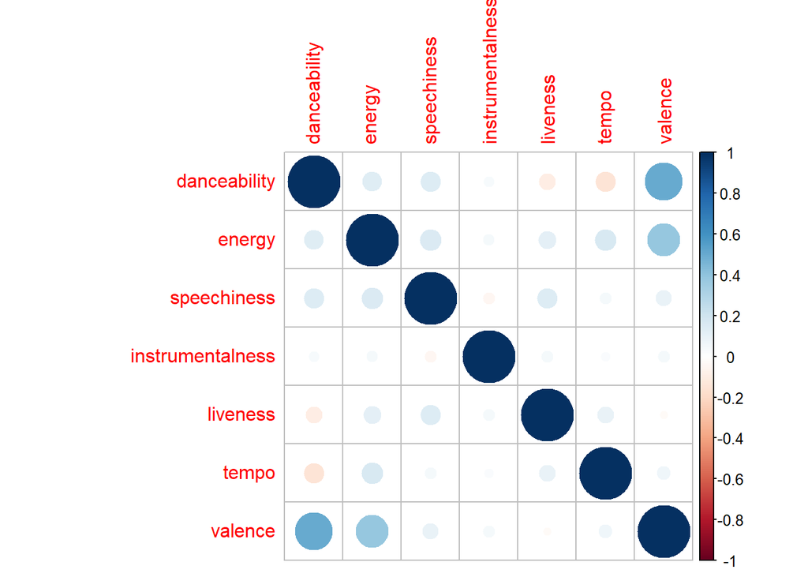

```r
corrplot(pl)
```

as you can see we can use danceability, energy and tempo to predict valnce.

```r
index = sample(x= setdiff(1:nrow(temp) , c(692 , 524 , 1299)),size = (0.8*nrow(temp) - 3)  ,replace = F)
train = temp[index,]
test =  temp[-index,]
test$predict = predict(fit , test , type = "response")
test <- test %>% mutate(error = (valence - predict)^2)
test_error = sum(test$error)
error <- sqrt(test_error)/nrow(test)
print("error of our prediction is : ")
```

```
## [1] "error of our prediction is : "
```

```r
error
```

```
## [1] 0.01323733
```

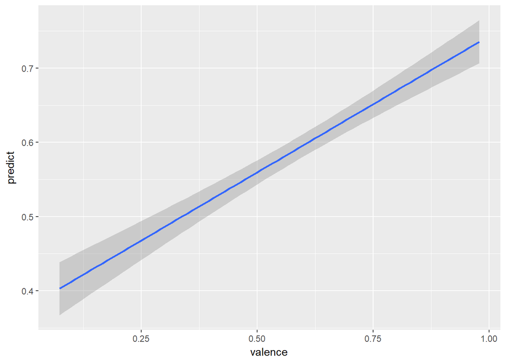

```r
ggplot(test, aes(x = valence, y = predict)) + geom_smooth(method = lm)
```

```r
final_test_var <- var(test$predict)
test_r2 <- 1 - (final_test_var / test_error)
print("R2 of our model is : ")
```

```
## [1] "R2 of our model is : "
```

```r
test_r2
```

```
## [1] 0.9972085
```

as you can see the error is 0.013 so our conclusion is that we can predict the valence. Actually spotify app uses these factors to predict the valence of musics.

# Now we work on some user data that includes the finding music listening habits.

number of plays of each month.

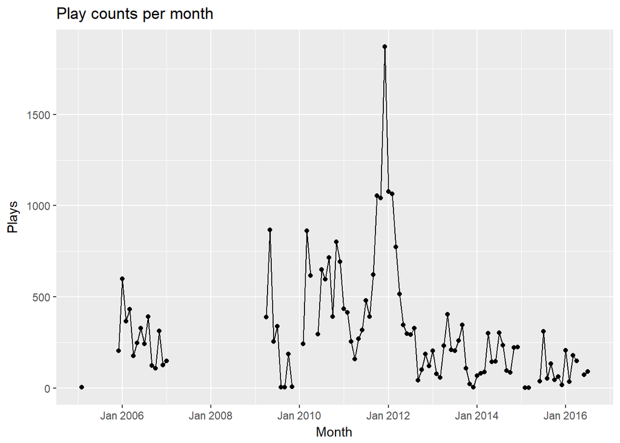

```r
load("data/tidy_scrobbles_with_genres.RData")
clean_scrobbles %>%
  count(yrmth = as.yearmon(date)) %>%
  complete(yrmth = full_seq_yearmon(yrmth)) %>%
  ggplot(aes(yrmth, n)) + geom_line() + geom_point() +
  scale_x_yearmon() +
  labs(x = "Month", y = "Plays", title = "Play counts per month")
```

```r
ggsave("output/overall.png", width = 6, height = 3)
```

Top artists.

```r
top_artists <- clean_scrobbles %>%
  count(artist, genre, sort = T) %>%
  ungroup() %>%
  top_n(20)
```

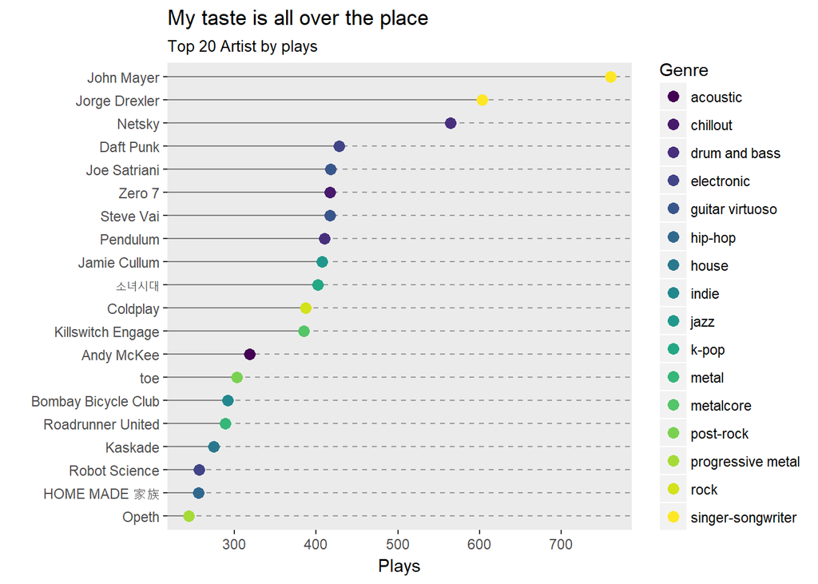

```r
top_artists %>%
  ggplot(aes(reorder(artist, n), n, color = genre)) +
   geom_segment(aes(xend = reorder(artist, n)), yend = 0, color = 'grey50') +
     geom_point(size = 3) +
  coord_flip() +
  labs(y = "Plays", x = "", title = "My taste is all over the place",
       subtitle = "Top 20 Artist by plays")+
  scale_color_viridis(discrete = T, name = "Genre") +
  theme(panel.grid.major.x = element_blank(),
        panel.grid.minor.x = element_blank(),
        panel.grid.major.y = element_line(color = 'grey60', linetype = 'dashed'))
```

```r
ggsave("output/top_artists.png", width = 5, height = 6)
```

Top artists of past years.

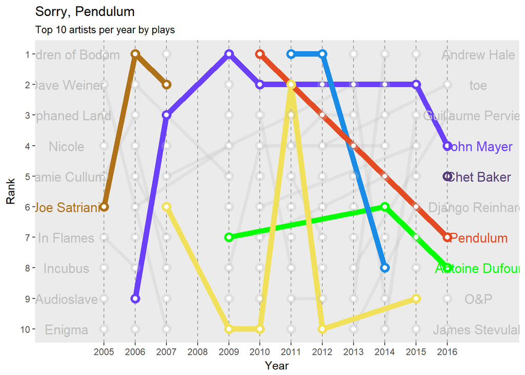

```r
tops <- 10
artist_ranking <- clean_scrobbles %>%
  count(year = year(date), artist) %>%
  group_by(year) %>%
  mutate(rank = row_number(-n)) %>%
  filter(rank < tops + 1)

artist_end_tags <- artist_ranking %>%
  ungroup() %>%
  filter(year == max(year)) %>%
  mutate(year = as.numeric(year) + 0.25)

artist_start_tags <- artist_ranking %>%
  ungroup() %>%
  filter(year == min(year)) %>%
  mutate(year = as.numeric(year) - 0.25)

colors <- c("John Mayer" = "#6a40fd", "Netsky" = "#198ce7", "Chet Baker" = "#563d7c", "Jorge Drexler" = "#f1e05a",
            "Joe Satriani" = "#b07219", "Pendulum" = "#e44b23", "Antoine Dufour" = "green")

othertags <- artist_ranking %>% distinct(artist) %>% filter(!artist %in% names(colors)) %>% .$artist

colors <- c(colors, setNames(rep("gray", length(othertags)), othertags))

highlights <- filter(artist_ranking, artist %in% names(colors)[colors != "gray"])

ggplot(data = artist_ranking, aes(year, rank, color = artist, group = artist, label = artist)) +
  geom_line(size = 1.7, alpha = 0.25) +
  geom_line(size = 2.5, data = highlights) +
  geom_point(size = 4, alpha = 0.25) +
  geom_point(size = 4, data = highlights) +
  geom_point(size = 1.75, color = "white") +
  geom_text(data = artist_start_tags, x = 2003.8, size = 4.5) +
  geom_text(data = artist_end_tags, x = 2017, size = 4.5) +
  scale_y_reverse(breaks = 1:tops) +
  scale_x_continuous(
    breaks = seq(min(artist_ranking$year), max(artist_ranking$year)),
    limits = c(min(artist_ranking$year) - 1.5, max(artist_ranking$year) + 1.6)) +
  scale_color_manual(values = colors)  + theme(
    legend.position = "",
    panel.grid.major.y = element_blank(),
    panel.grid.minor.y = element_blank(),
    panel.grid.minor.x = element_blank(),
    panel.grid.major.x = element_line(color = 'grey60', linetype = 'dashed')) +
  labs(x = "Year", y = "Rank", title = "Sorry, Pendulum",
       subtitle = "Top 10 artists per year by plays")
```

```r
ggsave("output/artists_over_time.png", width = 13, height = 5.6)
```

Top 10 Songs.

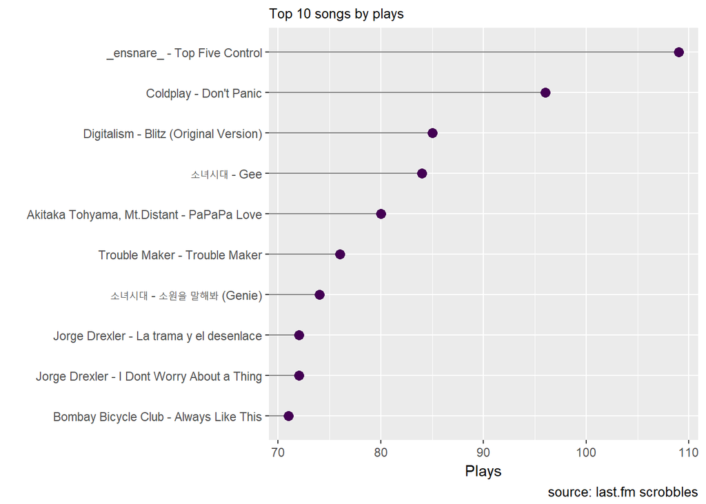

```r
clean_scrobbles %>%
  count(song, artist, sort = T) %>%
  ungroup() %>%
  top_n(10) %>%
  unite(fullname, artist, song, sep = " - ", remove = F) %>%
  ggplot(aes(reorder(fullname, n), n)) +
  geom_segment(aes(xend = reorder(fullname, n)), yend = 0, color = 'grey50') +
  geom_point(size = 3, color = viridis(1)) +
  scale_color_viridis() + coord_flip()  + theme(legend.position = "") +
  labs(x = "", y = "Plays",  subtitle = "Top 10 songs by plays",
       caption = "source: last.fm scrobbles")
```

```r
ggsave("output/top-20-songs.png", width = 5, height = 6)
```

Top genres

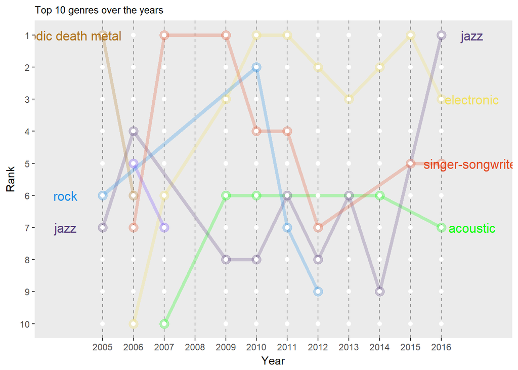

```r
tops <- 10

cleaner_scrobbles<- clean_scrobbles


ranking <- cleaner_scrobbles %>%
  filter(!is.na(genre) ) %>%
  count(year = year(date), genre) %>%
  group_by(year) %>%
  mutate(rank = row_number(-n)) %>%
  filter(rank < tops + 1)

end_tags <- ranking %>%
  ungroup() %>%
  filter(year == max(year)) %>%
  mutate(year = as.numeric(year) + 0.25)

start_tags <- ranking %>%
  ungroup() %>%
  filter(year == min(year)) %>%
  mutate(year = as.numeric(year) - 0.25)

highlight <- ranking %>% filter( genre %in% names(colors)[colors != "gray"])


colors <- c("metal" = "#6a40fd", "rock" = "#198ce7", "jazz" = "#563d7c", "electronic" = "#f1e05a",
            "melodic death metal" = "#b07219", "singer-songwriter" = "#e44b23", "acoustic" = "green")


colors <- c(colors, setNames(rep("gray", length(othertags)), othertags))



ggplot(data = ranking, aes(year, rank, color = genre, group = genre)) +
  geom_line(size = 1.7, alpha = 0.25) +
  geom_line(size = 2.5, data = highlight) +
  geom_point(size = 4, alpha = 0.25) +
  geom_point(size = 4, data = highlight) +
  geom_point(size = 1.75, color = "white") +
  geom_text(data = start_tags, aes(label = genre), x = 2003.8, size = 4.5) +
  geom_text(data = end_tags, aes(label = genre), x = 2017, size = 4.5) +
  scale_y_reverse(breaks = 1:tops) +
  scale_x_continuous(
    breaks = seq(min(ranking$year), max(ranking$year)),
    limits = c(min(ranking$year) - 1.5, max(ranking$year) + 1.6)) +
  scale_color_manual(values = colors)  + theme(
    legend.position = "",
    panel.grid.major.y = element_blank(),
    panel.grid.minor.y = element_blank(),
    panel.grid.minor.x = element_blank(),
    panel.grid.major.x = element_line(color = 'grey60', linetype = 'dashed')) +
  labs(x = "Year", y = "Rank",
       subtitle = "Top 10 genres over the years")
```

```r
ggsave("output/genre_overtime.png", height = 6, width = 12)
```